# Analyzing egocentric networks with R: A quick introduction

Raffaele Vacca

University of Milan  
[raffaelevacca.com](https://www.raffaelevacca.com/)

2022-06-22

This is a quick introduction to R packages and tools for egocentric network analysis, with a focus on [`igraph`](https://igraph.org/) and [`tidyverse`](https://www.tidyverse.org/). It’s a short version of a more extensive and in-depth [book on egocentric network analysis with R](https://raffaelevacca.github.io/egocentric-r-book/). I use these materials for teaching workshops on the subject at [INSNA Sunbelt](https://www.insna.org/)/[NetSci](https://netscisociety.net/home) conferences, the [UAB Barcelona Course on Personal Network Analysis](https://sway.office.com/1TpXMhGqKa7fTsAC), and the [University of Groningen Summer School on Migration, Integration, and Social Networks](https://www.rug.nl/education/summer-winter-schools/migration-integration-and-social-networks/?lang=en).

# 1 Setup and data

**Download links:**

- [GitHub repository](https://github.com/raffaelevacca/egocentric-r-short) for this project (to get and reproduce the code below):
  - Click on the link above > `Code` green button > Download ZIP
  - Unzip the folder and save it to your computer
- [Workshop slides](https://www.dropbox.com/sh/q7021q1adbf3e5j/AAC8aOdSRi5aCowcPUEGE4_Aa?dl=0)

**Also see the following links** (from the [longer version](https://raffaelevacca.github.io/egocentric-r-book/) of these materias) for:

- [Software setup](https://raffaelevacca.github.io/egocentric-r-book/index.html#setup)
- [Required R packages](https://raffaelevacca.github.io/egocentric-r-book/index.html#packages)
- [Documentation about the workshop data](https://raffaelevacca.github.io/egocentric-r-book/index.html#data)

```r
# Load all packages used in this script
library(tidyverse)
library(igraph)
library(ggraph)
library(skimr)
library(janitor)
library(magrittr)
```

# 2 Representing and visualizing ego-networks

This section covers the following topics:

- Representing ego-level attribute data and alter-level attribute data in R.
- Joining (merging) ego-level and alter-level data frames.
- Representing alter-alter tie data.
- Representing and manipulating an ego-network as an `igraph` object.
- Visualizing an ego-network.

## 2.1 Ego-level and alter-level data

- Egocentric network data typically include at least three types of data:
  - **Ego-level attribute data**. This is normally a dataset with attributes of the egos. Each row is an ego (typically, a survey respondent) and each column is a characteristic of the ego. Following multilevel modeling terminology, we call this “level 2” because, in the multilevel structure of ego-network data, egos are the higher-level “groups” in which alters are clustered. In personal network surveys, these data are obtained from standard survey questions asking individual information about the respondent.
  - **Alter-level attribute data**. This is a dataset with attributes of alters and of ego-alter ties. It is also the dataset that, for each alter, indicates who is the ego who nominated that alter: that is, it lists all the ego-alter ties. In this dataset, each row is an alter and each column is a characteristic of the alter, or of the relationship between the alter and the ego who nominated him/her. Following multilevel modeling terminology, we call this “level 1” because alters are the most granular units in the data, clustered within egos. In personal network surveys, these data are obtained from the so-called *name generator* questions, which elicit lists of alters from each ego; and from the *name interpreter* questions, which elicit characteristics of each alter.
  - **Alter-alter tie data**. These are the data about alter-alter ties as reported by the ego. In personal network surveys, these data are obtained from so-called *edge interpreter* questions.
- **File formats:**
  - Ego-level attribute data. This is normally a single dataset (in a single file), with each row representing one ego, and different columns representing different ego-level attributes. This is similar to any respondent-level dataset you have in standard survey data.
  - Alter-level attribute data. Depending on the data collection software, you might have a single dataset (in a single file) including alters nominated by all egos; or separate datasets (in separate files), one for each ego, with the alters nominated by that ego (and with the same variables in all datasets).
  - Alter-alter tie data. These are typically in edge list format or in adjacency matrix format, depending on the data collection software. If the tie data are in adjacency matrices, you normally have a separate adjacency matrix for each ego, in a separate file. If they are in edge lists, you might have a single edge list including alters from all egos (with an additional column indicating the ego that nominated the two alters), or a separate edge list (in a separate file) for each ego.
- The data format described above works well because, in standard egocentric data, the different ego-networks are **separate** (non-overlapping). This means that an alter can only “belong” to one and one only ego, and alter-alter ties only exist between alters nominated by the same egos. In other words, there are no links or overlaps between the networks of different egos.
  - In particular, this means that there is a one-to-one correspondence between alters and ego-alter ties: for each ego-alter tie there is only one alter, and vice versa (so the level of alters is the same as the level of ego-alter ties).
- In egocentric analysis you are frequently switching between level 1 and 2, and **joining** information from the two levels.
- **Level-1 join.** Bring information from level 2 into the level-1 dataset.
  - For certain types of analysis you need to join ego attributes (level 2) into an alter-level data set (level 1).
  - For example, you need to do this when estimating multilevel models in which the dependent variable is a characteristic of ego-alter ties (e.g., if the tie provides support), and some of the predictors are ego-level characteristics (e.g., gender of the ego).
  - Because there is one ego for multiple alters, this is a one-to-many join, with the same value of an ego attribute (one ego row in the level-2 dataset) being joined to multiple alters (multiple alter rows in the level-1 dataset).
  - The data frames are joined by ego ID.
- **Level-2 join.** Bring information from level 1 into the level-2 dataset.
  - In other cases you want to join alter attributes (level 1) into an ego-level dataset (level 2).
  - For example, you need to do this when you want to analyze summary measures of ego-network characteristics (e.g. average age of alters) among the egos.
  - Because there are multiple alters for one ego, this requires that you first summarize or aggregate the alter attributes for each ego.
  - If you have *continuous* alter attributes, you typically summarize them by taking averages and dispersion measures (variance, standard deviation, etc.) of the alter attribute for each ego: for example, average alter age for each ego, or standard deviation of contact frequency between alters and each ego.
  - If you have *categorical* alter attributes, you normally summarize them by taking counts or proportions of certain categories, or qualitative diversity measures (e.g., generalized variance, entropy): for example, proportion of women, or ethnic diversity in each ego’s network.
  - Once you have these summary variables on ego-network *composition*, you can join them with an ego-level dataset by ego ID.
  - The level-2 join can also involve summary variables on ego-network *structure*: for example, average alter degree, ego-network density, or number of components. These variables can be joined with an ego-level dataset by ego ID.
- We’ll consider this type of ego-level summarization and the level-2 join in the sections about measures of ego-network composition and structure.

```r
# Load the data.
load("./Data/data.rda")

# The file we just loaded includes the following objects.

# * Ego-level attribute data
ego.df
```

```
## # A tibble: 102 × 9
##    ego_ID ego.sex ego.age ego.arr ego.edu ego.inc  empl ego.empl.bin ego.age.cat
##     <dbl> <fct>     <dbl>   <dbl> <fct>     <dbl> <dbl> <fct>        <fct>
##  1     28 Male         61    2008 Second…     350     3 Yes          60+
##  2     29 Male         38    2000 Primary     900     4 Yes          36-40
##  3     33 Male         30    2010 Primary     200     3 Yes          26-30
##  4     35 Male         25    2009 Second…    1000     3 Yes          18-25
##  5     39 Male         29    2007 Primary       0     1 No           26-30
##  6     40 Male         56    2008 Second…     950     4 Yes          51-60
##  7     45 Male         52    1975 Primary    1600     3 Yes          51-60
##  8     46 Male         35    2002 Second…    1200     4 Yes          31-35
##  9     47 Male         22    2010 Second…     700     4 Yes          18-25
## 10     48 Male         51    2007 Primary     950     4 Yes          51-60
## # … with 92 more rows
```

```r
# * Attribute data for alters and ego-alter ties (all alters and ego-alter ties
# in one data frame).
alter.attr.all
```

```
## # A tibble: 4,590 × 12
##    alter_ID ego_ID alter_num alter.sex alter.age.cat alter.rel    alter.nat
##       <dbl>  <dbl>     <dbl> <fct>     <fct>         <fct>        <fct>
##  1     2801     28         1 Female    51-60         Close family Sri Lanka
##  2     2802     28         2 Male      51-60         Other family Sri Lanka
##  3     2803     28         3 Male      51-60         Close family Sri Lanka
##  4     2804     28         4 Male      60+           Close family Sri Lanka
##  5     2805     28         5 Female    41-50         Close family Sri Lanka
##  6     2806     28         6 Female    60+           Close family Sri Lanka
##  7     2807     28         7 Male      41-50         Other family Sri Lanka
##  8     2808     28         8 Female    36-40         Other family Sri Lanka
##  9     2809     28         9 Female    51-60         Other family Sri Lanka
## 10     2810     28        10 Male      60+           Other family Sri Lanka
## # … with 4,580 more rows, and 5 more variables: alter.res <fct>,
## #   alter.clo <dbl>, alter.loan <fct>, alter.fam <fct>, alter.age <dbl>
```

```r
# Level-1 join: Ego attributes into alter-level data (one to many).
(data <- left_join(alter.attr.all, ego.df, by= "ego_ID"))
```

```
## # A tibble: 4,590 × 20
##    alter_ID ego_ID alter_num alter.sex alter.age.cat alter.rel    alter.nat
##       <dbl>  <dbl>     <dbl> <fct>     <fct>         <fct>        <fct>
##  1     2801     28         1 Female    51-60         Close family Sri Lanka
##  2     2802     28         2 Male      51-60         Other family Sri Lanka
##  3     2803     28         3 Male      51-60         Close family Sri Lanka
##  4     2804     28         4 Male      60+           Close family Sri Lanka
##  5     2805     28         5 Female    41-50         Close family Sri Lanka
##  6     2806     28         6 Female    60+           Close family Sri Lanka
##  7     2807     28         7 Male      41-50         Other family Sri Lanka
##  8     2808     28         8 Female    36-40         Other family Sri Lanka
##  9     2809     28         9 Female    51-60         Other family Sri Lanka
## 10     2810     28        10 Male      60+           Other family Sri Lanka
## # … with 4,580 more rows, and 13 more variables: alter.res <fct>,
## #   alter.clo <dbl>, alter.loan <fct>, alter.fam <fct>, alter.age <dbl>,
## #   ego.sex <fct>, ego.age <dbl>, ego.arr <dbl>, ego.edu <fct>, ego.inc <dbl>,
## #   empl <dbl>, ego.empl.bin <fct>, ego.age.cat <fct>
```

```r
# Note that the new data frame has one row for each alter, and the same ego ID
# and ego attribute value is repeated for all alters belonging to the same ego.
data %>%
  dplyr::select(alter_ID, ego_ID, ego.age, ego.edu)
```

```
## # A tibble: 4,590 × 4
##    alter_ID ego_ID ego.age ego.edu
##       <dbl>  <dbl>   <dbl> <fct>
##  1     2801     28      61 Secondary
##  2     2802     28      61 Secondary
##  3     2803     28      61 Secondary
##  4     2804     28      61 Secondary
##  5     2805     28      61 Secondary
##  6     2806     28      61 Secondary
##  7     2807     28      61 Secondary
##  8     2808     28      61 Secondary
##  9     2809     28      61 Secondary
## 10     2810     28      61 Secondary
## # … with 4,580 more rows
```

## 2.2 Ego-networks as `igraph` objects

```r
# The data.rda file, which we loaded earlier, also includes the ego-network of
# ego 28 (as igraph object)
gr.28
```

```
## IGRAPH 9d3433d UNW- 45 259 --
## + attr: .egoID (g/n), ego_ID (g/c), name (v/c), alter_num (v/n),
## | alter.sex (v/c), alter.age.cat (v/c), alter.rel (v/c), alter.nat
## | (v/c), alter.res (v/c), alter.clo (v/n), alter.loan (v/c), alter.fam
## | (v/c), alter.age (v/n), weight (e/n)
## + edges from 9d3433d (vertex names):
##  [1] 2801--2802 2801--2803 2801--2804 2801--2805 2801--2806 2801--2807
##  [7] 2801--2808 2801--2809 2801--2810 2801--2811 2801--2812 2801--2813
## [13] 2801--2814 2801--2815 2801--2818 2801--2820 2801--2823 2801--2825
## [19] 2801--2827 2801--2828 2801--2829 2801--2831 2801--2840 2801--2841
## [25] 2802--2803 2802--2804 2802--2805 2802--2806 2802--2807 2802--2808
## + ... omitted several edges
```

```r
# The graph is Undirected, Named, Weighted. It has 45 vertices and 259 edges. It
# has a vertex attribute called "name", and an edge attribute called "weight".
# We see several vertex attributes (see codebook.xlsx for their meaning).

# Let's reassign it to a new, generic object name. This makes the code more
# generic and more easily re-usable on any ego-network igraph object
# (of any ego ID).
gr <- gr.28

# We also have the same network, with ego included: note the different number
# of vertices and edges compared to the previous graph.
gr.ego.28
```

```
## IGRAPH d6524fd UNW- 46 304 --
## + attr: .egoID (g/n), ego_ID (g/c), name (v/c), alter_num (v/n),
## | alter.sex (v/c), alter.age.cat (v/c), alter.rel (v/c), alter.nat
## | (v/c), alter.res (v/c), alter.clo (v/n), alter.loan (v/c), alter.fam
## | (v/c), alter.age (v/n), weight (e/n)
## + edges from d6524fd (vertex names):
##  [1] 2801--2802 2801--2803 2801--2804 2801--2805 2801--2806 2801--2807
##  [7] 2801--2808 2801--2809 2801--2810 2801--2811 2801--2812 2801--2813
## [13] 2801--2814 2801--2815 2801--2818 2801--2820 2801--2823 2801--2825
## [19] 2801--2827 2801--2828 2801--2829 2801--2831 2801--2840 2801--2841
## [25] 2802--2803 2802--2804 2802--2805 2802--2806 2802--2807 2802--2808
## + ... omitted several edges
```

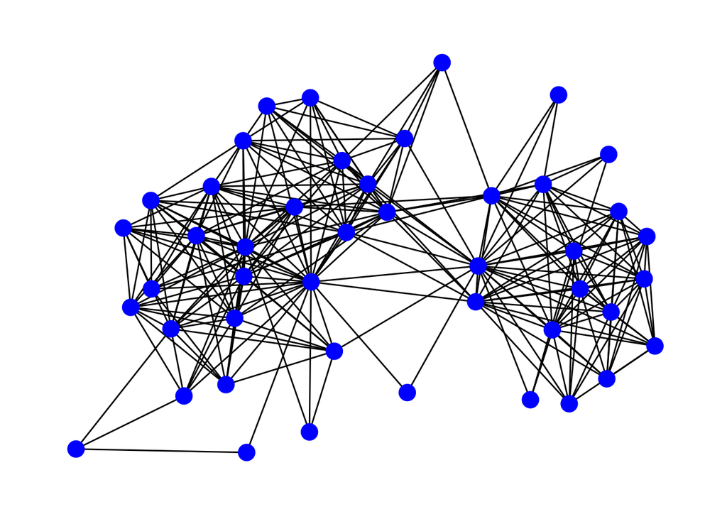

```r
gr.ego <- gr.ego.28

# Show the graph. Note that ego is not included.
set.seed(607)
ggraph(gr) +
  geom_edge_link() + # Draw edges
  geom_node_point(size=5, color="blue") + # Draw nodes
  theme_graph(base_family = 'Helvetica') # Set graph theme and font
```

```r
# Vertex and edge sequences and attributes                                  ----
# - - - - - - - - - - - - - - - - - - - - - - - - - - - - - - - - - - - - - - -

# Vertex sequences and edge sequences can be extracted from a graph.

# Vertex sequence of the whole graph. Notice that vertices are displayed by
# "names" (alter IDs in this case).
V(gr)
```

```
## + 45/45 vertices, named, from 9d3433d:
##  [1] 2801 2802 2803 2804 2805 2806 2807 2808 2809 2810 2811 2812 2813 2814 2815
## [16] 2816 2817 2818 2819 2820 2821 2822 2823 2824 2825 2826 2827 2828 2829 2830
## [31] 2831 2832 2833 2834 2835 2836 2837 2838 2839 2840 2841 2842 2843 2844 2845
```

```r
# Edge sequence of the whole graph. Notice that vertex names (alter IDs) are
# used here too.
E(gr)
```

```
## + 259/259 edges from 9d3433d (vertex names):
##  [1] 2801--2802 2801--2803 2801--2804 2801--2805 2801--2806 2801--2807
##  [7] 2801--2808 2801--2809 2801--2810 2801--2811 2801--2812 2801--2813
## [13] 2801--2814 2801--2815 2801--2818 2801--2820 2801--2823 2801--2825
## [19] 2801--2827 2801--2828 2801--2829 2801--2831 2801--2840 2801--2841
## [25] 2802--2803 2802--2804 2802--2805 2802--2806 2802--2807 2802--2808
## [31] 2802--2809 2802--2810 2802--2811 2802--2812 2802--2813 2802--2815
## [37] 2802--2823 2802--2831 2802--2840 2802--2841 2803--2804 2803--2805
## [43] 2803--2806 2803--2807 2803--2808 2803--2809 2803--2810 2803--2811
## [49] 2803--2812 2803--2840 2803--2841 2804--2805 2804--2806 2804--2807
## [55] 2804--2808 2804--2809 2804--2810 2804--2811 2804--2840 2804--2841
## + ... omitted several edges
```

```r
# View vertex attributes and calculate statistics on them.

# Closeness of alters to ego.
V(gr)$alter.clo
```

```
##  [1] NA  3 NA NA NA NA  5  4  5  5  5  4  3  5  3  3  1  5  4  5  5  5  5  5  2
## [26]  3  4  5  5  5  5  3  5  3  4  5  5  5  5  3  3  3  3  3  5
```

```r
# Mean closeness of alters to ego.
V(gr)$alter.clo %>%
mean(na.rm=TRUE)
```

```
## [1] 4.1
```

```r
# The previous line uses the pipe operator: it's the same as the following
mean(V(gr)$alter.clo, na.rm=TRUE)
```

```
## [1] 4.1
```

```r
# More descriptive statistics on alter closeness.
V(gr)$alter.clo %>%
skimr::skim_tee()
```

```
## ── Data Summary ────────────────────────
##                            Values
## Name                       data
## Number of rows             45
## Number of columns          1
## _______________________
## Column type frequency:
##   numeric                  1
## ________________________
## Group variables            None
##
## ── Variable type: numeric ──────────────────────────────────────────────────────
##   skim_variable n_missing complete_rate  mean    sd    p0   p25   p50   p75
## 1 data                  5         0.889   4.1  1.08     1     3     5     5
##    p100 hist
## 1     5 ▁▁▅▂▇
```

```r
# Alter's country of residence.
V(gr)$alter.res
```

```
##  [1] "Sri Lanka" "Sri Lanka" "Sri Lanka" "Sri Lanka" "Sri Lanka" "Sri Lanka"
##  [7] "Sri Lanka" "Sri Lanka" "Sri Lanka" "Sri Lanka" "Sri Lanka" "Sri Lanka"
## [13] "Italy"     "Italy"     "Italy"     "Italy"     "Italy"     "Italy"
## [19] "Italy"     "Other"     "Italy"     "Italy"     "Italy"     "Italy"
## [25] "Italy"     "Italy"     "Sri Lanka" "Sri Lanka" "Sri Lanka" "Italy"
## [31] "Italy"     "Italy"     "Italy"     "Italy"     "Italy"     "Italy"
## [37] "Italy"     "Italy"     "Italy"     "Sri Lanka" "Sri Lanka" "Italy"
## [43] "Italy"     "Italy"     "Italy"
```

```r
# Frequencies.
V(gr)$alter.res %>%
janitor::tabyl()
```

```
##          .  n    percent
##      Italy 27 0.60000000
##      Other  1 0.02222222
##  Sri Lanka 17 0.37777778
```

```r
# Alter IDs are stored in the "name" vertex attribute
V(gr)$name
```

```
##  [1] "2801" "2802" "2803" "2804" "2805" "2806" "2807" "2808" "2809" "2810"
## [11] "2811" "2812" "2813" "2814" "2815" "2816" "2817" "2818" "2819" "2820"
## [21] "2821" "2822" "2823" "2824" "2825" "2826" "2827" "2828" "2829" "2830"
## [31] "2831" "2832" "2833" "2834" "2835" "2836" "2837" "2838" "2839" "2840"
## [41] "2841" "2842" "2843" "2844" "2845"
```

```r
# Also edges have attributes, in this case "weight".
E(gr)$weight
```

```
##   [1] 1 1 1 1 1 1 1 1 1 1 1 1 1 1 2 1 1 1 1 1 2 1 1 1 1 1 1 1 1 1 1 1 1 1 1 1 1
##  [38] 1 1 1 1 1 1 1 1 1 1 1 1 1 1 1 1 1 1 1 1 2 2 1 1 1 1 1 1 1 1 1 1 1 1 1 1 1
##  [75] 1 1 1 1 1 2 1 1 1 1 1 1 1 1 1 1 2 2 1 1 1 1 1 1 1 1 1 1 1 1 1 1 1 2 1 2 1
## [112] 1 1 1 1 1 1 1 1 2 1 1 1 1 1 1 1 1 1 1 2 1 1 1 1 1 1 1 1 2 1 1 1 1 2 1 1 1
## [149] 1 1 1 1 1 1 1 2 2 1 1 2 1 1 1 1 1 1 1 1 1 1 1 1 1 1 1 1 1 1 2 1 1 1 1 1 1
## [186] 1 1 1 1 1 1 1 1 1 1 1 2 1 1 1 1 1 1 1 1 1 1 2 1 1 1 1 2 1 1 2 1 1 1 1 1 1
## [223] 1 1 1 1 1 1 1 2 1 1 1 1 2 1 1 1 1 1 1 1 1 1 1 1 1 1 1 1 1 1 1 1 1 1 2 1 1
```

```r
# Frequencies of edge weights.
E(gr)$weight %>%
tabyl()
```

```
##  .   n    percent
##  1 235 0.90733591
##  2  24 0.09266409
```

```r
# Displaying vertex attributes in network visualization                     ----
# - - - - - - - - - - - - - - - - - - - - - - - - - - - - - - - - - - - - - - -

# Let's visualize our ego-network, using different node colors for different
# countries of residence of alters.

# Vertex attribute with alter's country of residence.
V(gr)$alter.res
```

```
##  [1] "Sri Lanka" "Sri Lanka" "Sri Lanka" "Sri Lanka" "Sri Lanka" "Sri Lanka"
##  [7] "Sri Lanka" "Sri Lanka" "Sri Lanka" "Sri Lanka" "Sri Lanka" "Sri Lanka"
## [13] "Italy"     "Italy"     "Italy"     "Italy"     "Italy"     "Italy"
## [19] "Italy"     "Other"     "Italy"     "Italy"     "Italy"     "Italy"
## [25] "Italy"     "Italy"     "Sri Lanka" "Sri Lanka" "Sri Lanka" "Italy"
## [31] "Italy"     "Italy"     "Italy"     "Italy"     "Italy"     "Italy"
## [37] "Italy"     "Italy"     "Italy"     "Sri Lanka" "Sri Lanka" "Italy"
## [43] "Italy"     "Italy"     "Italy"
```

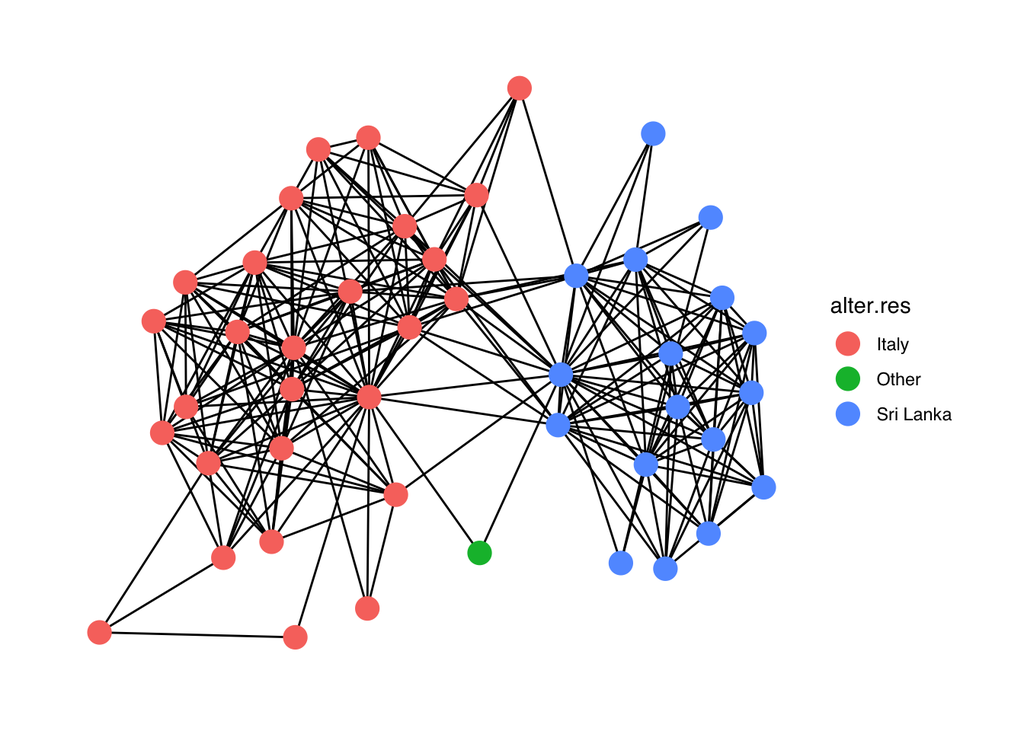

```r
# Plot with alter.res as node color
set.seed(607)
ggraph(gr) +
  geom_edge_link() + # Draw edges
  geom_node_point(aes(color= alter.res), size=5) + # Draw nodes setting alter.res
  # as node color and fixed node size
  theme_graph(base_family = 'Helvetica')
```

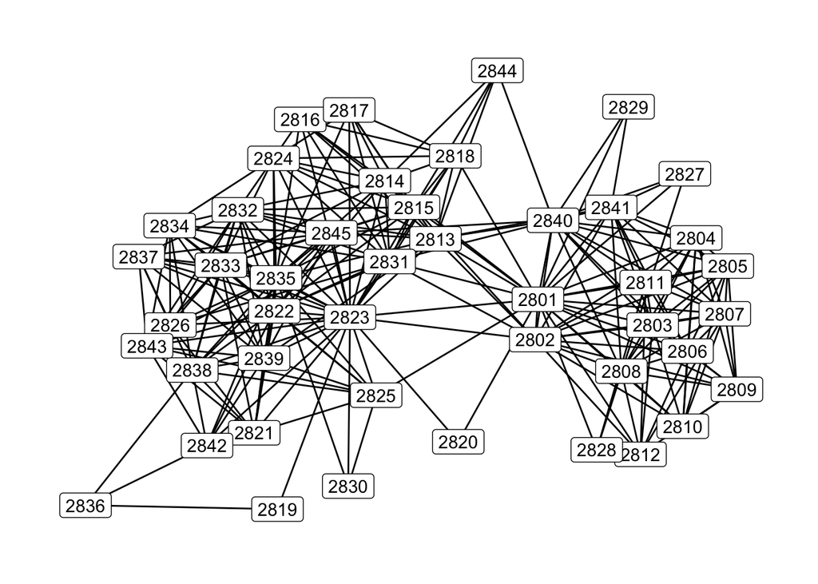

```r
# Plot with alter ID labels instead of circles
set.seed(607)
ggraph(gr) +
  geom_edge_link() +
  geom_node_label(aes(label= name)) +
  theme_graph(base_family = 'Helvetica')
```

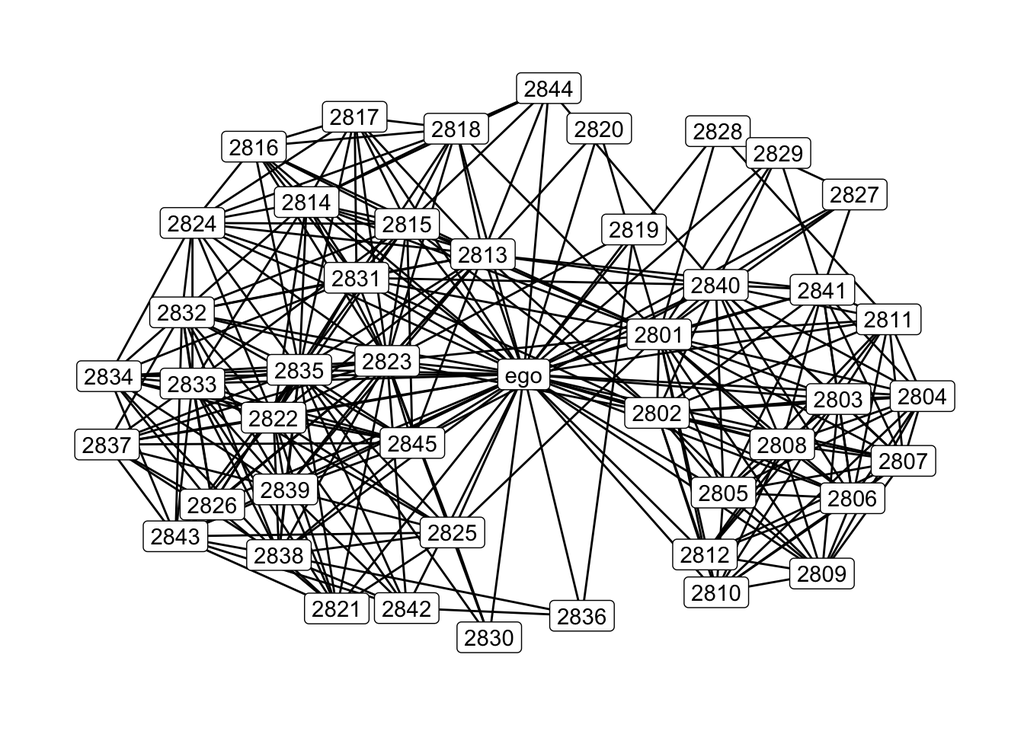

```r
# Let's look at the same network, but with ego included
set.seed(607)
ggraph(gr.ego) +
  geom_edge_link() +
  geom_node_label(aes(label= name)) +
  theme_graph(base_family = 'Helvetica')
```

# 3 Ego-network composition

- Ego-network composition refers to the distribution of attributes of alters (for example, age or race/ethnicity) or attributes of ego-alter ties (for example, closeness or frequency of contact). For brevity, these are often called simply *alter attributes* in the following text.
- We consider composition by first analyzing just one ego-network, then replicating the same type of analysis on many ego-networks at once.
- This section covers the following topics:
  - Calculating measures of composition for one ego-network.
  - Representing data from multiple ego-networks as data frames.
  - Running the same operation on many ego-networks and combining results back together (split-apply-combine).
  - Split-apply-combine on data frames with `dplyr` to analyze the composition of many ego-networks at once.

## 3.1 Measures of ego-network composition

- Many different measures can be calculated to describe ego-network composition.
  - The result is typically an ego-level summary variable: one that assigns a number to each ego, with that number describing a characteristic of the ego-network composition for each ego.
- To calculate compositional measures we don’t need any network or relational data (data about alter-alter ties), we only need the alter-level attribute dataset (for example, with alter age, gender, ethnicity, frequency of contact, etc.). In other words, we only need, for each ego, a list of alters with their characteristics, and no information about ties between alters.
  - So in this section, ego-networks are represented simply by alter-level data frames. We don’t need to work with the `igraph` network objects until we want to analyze ego-network structure (alter-alter ties).
- **What we do in the following code**.
  - Look at the alter attribute data frame for one ego.
  - Using this data frame, calculate compositional measures based on one alter attribute.
  - Do the level-1 join: join ego attributes into alter-level data.
  - Using the joined data, calculate compositional measures of homophily between ego and alters.
  - Calculate multiple compositional measures and put them together into one ego-level data frame.

```r
# For compositional measures all we need is the alter attribute data frame.
# The data.rda file loaded above includes the alter attribute data frame for
# ego ID 28.
alter.attr.28
```

```
## # A tibble: 45 × 12
##    alter_ID ego_ID alter_num alter.sex alter.age.cat alter.rel    alter.nat
##       <dbl>  <dbl>     <dbl> <fct>     <fct>         <fct>        <fct>
##  1     2801     28         1 Female    51-60         Close family Sri Lanka
##  2     2802     28         2 Male      51-60         Other family Sri Lanka
##  3     2803     28         3 Male      51-60         Close family Sri Lanka
##  4     2804     28         4 Male      60+           Close family Sri Lanka
##  5     2805     28         5 Female    41-50         Close family Sri Lanka
##  6     2806     28         6 Female    60+           Close family Sri Lanka
##  7     2807     28         7 Male      41-50         Other family Sri Lanka
##  8     2808     28         8 Female    36-40         Other family Sri Lanka
##  9     2809     28         9 Female    51-60         Other family Sri Lanka
## 10     2810     28        10 Male      60+           Other family Sri Lanka
## # … with 35 more rows, and 5 more variables: alter.res <fct>, alter.clo <dbl>,
## #   alter.loan <fct>, alter.fam <fct>, alter.age <dbl>
```

```r
# Compositional measures based on an alter attribute                  ----
# - - - - - - - - - - - - - - - - - - - - - - - - - - - - - - - - - - - - - - -

# Summary of continuous variable: Average alter closeness.

# Check out the relevant variable
alter.attr.28 %>%
  pull(alter.clo)
```

```
##  [1] NA  3 NA NA NA NA  5  4  5  5  5  4  3  5  3  3  1  5  4  5  5  5  5  5  2
## [26]  3  4  5  5  5  5  3  5  3  4  5  5  5  5  3  3  3  3  3  5
```

```r
# Battery of descriptive stats.
alter.attr.28 %>%
  skim_tee(alter.clo)
```

```
## ── Data Summary ────────────────────────
##                            Values
## Name                       data
## Number of rows             45
## Number of columns          12
## _______________________
## Column type frequency:
##   numeric                  1
## ________________________
## Group variables            None
##
## ── Variable type: numeric ──────────────────────────────────────────────────────
##   skim_variable n_missing complete_rate  mean    sd    p0   p25   p50   p75
## 1 alter.clo             5         0.889   4.1  1.08     1     3     5     5
##    p100 hist
## 1     5 ▁▁▅▂▇
```

```r
# Get a single summary measure (useful when writing functions)
mean(alter.attr.28$alter.clo, na.rm = TRUE)
```

```
## [1] 4.1
```

```r
# Summary of categorical variable: Proportion female alters.

# Check out the relevant vector
alter.attr.28$alter.sex
```

```
##  [1] Female Male   Male   Male   Female Female Male   Female Female Male
## [11] Male   Male   Male   Male   Male   Male   Male   Male   Male   Male
## [21] Male   Male   Male   Male   Male   Male   Male   Female Male   Male
## [31] Male   Female Male   Male   Male   Male   Female Male   Male   Male
## [41] Male   Male   Male   Male   Male
## Levels: Female Male
```

```r
# Get frequencies
alter.attr.28 %>%
  tabyl(alter.sex)
```

```
##  alter.sex  n   percent
##     Female  8 0.1777778
##       Male 37 0.8222222
```

```r
# Same for nationalities
alter.attr.28 %>%
  tabyl(alter.nat)
```

```
##  alter.nat  n    percent
##      Italy  0 0.00000000
##      Other  2 0.04444444
##  Sri Lanka 43 0.95555556
```

```r
# Another way to get the proportion of a specific category (this is useful when
# writing functions).
mean(alter.attr.28$alter.sex == "Female")
```

```
## [1] 0.1777778
```

```r
mean(alter.attr.28$alter.nat == "Sri Lanka")
```

```
## [1] 0.9555556
```

```r
# The function dplyr::summarise() allows us to calculate multiple measures, name
# them, and put them together in a data frame.
alter.attr.28 %>%
  summarise(
    mean.clo = mean(alter.clo, na.rm=TRUE),
    prop.fem = mean(alter.sex=="Female"),
    count.nat.slk = sum(alter.nat=="Sri Lanka"),
    count.nat.ita = sum(alter.nat=="Italy"),
    count.nat.oth = sum(alter.nat=="Other")
  )
```

```
## # A tibble: 1 × 5
##   mean.clo prop.fem count.nat.slk count.nat.ita count.nat.oth
##      <dbl>    <dbl>         <int>         <int>         <int>
## 1      4.1    0.178            43             0             2
```

```r
# What if we want to calculate the same measures for all ego-networks in the data?
# We'll have to use the data frame with all alter attributes from all egos.
alter.attr.all
```

```
## # A tibble: 4,590 × 12
##    alter_ID ego_ID alter_num alter.sex alter.age.cat alter.rel    alter.nat
##       <dbl>  <dbl>     <dbl> <fct>     <fct>         <fct>        <fct>
##  1     2801     28         1 Female    51-60         Close family Sri Lanka
##  2     2802     28         2 Male      51-60         Other family Sri Lanka
##  3     2803     28         3 Male      51-60         Close family Sri Lanka
##  4     2804     28         4 Male      60+           Close family Sri Lanka
##  5     2805     28         5 Female    41-50         Close family Sri Lanka
##  6     2806     28         6 Female    60+           Close family Sri Lanka
##  7     2807     28         7 Male      41-50         Other family Sri Lanka
##  8     2808     28         8 Female    36-40         Other family Sri Lanka
##  9     2809     28         9 Female    51-60         Other family Sri Lanka
## 10     2810     28        10 Male      60+           Other family Sri Lanka
## # … with 4,580 more rows, and 5 more variables: alter.res <fct>,
## #   alter.clo <dbl>, alter.loan <fct>, alter.fam <fct>, alter.age <dbl>
```

```r
# dplyr allows us to "group" a data frame by a factor (here, ego IDs) so all
# measures we calculate on that data frame via summarise (means, proportions,
# etc.) are calculated by the groups given by that factor (here, for each ego
# ID).
alter.attr.all %>%
  group_by(ego_ID) %>%
  summarise(
    mean.clo = mean(alter.clo, na.rm=TRUE),
    prop.fem = mean(alter.sex=="Female"),
    count.nat.slk = sum(alter.nat=="Sri Lanka"),
    count.nat.ita = sum(alter.nat=="Italy"),
    count.nat.oth = sum(alter.nat=="Other")
  )
```

```
## # A tibble: 102 × 6
##    ego_ID mean.clo prop.fem count.nat.slk count.nat.ita count.nat.oth
##     <dbl>    <dbl>    <dbl>         <int>         <int>         <int>
##  1     28     4.1    0.178             43             0             2
##  2     29     4.03   0.0889            44             1             0
##  3     33     3.62   0.378             32             2            11
##  4     35     3.78   0.289             33             4             8
##  5     39     3.73   0.244             39             5             1
##  6     40     3.32   0.356             34             1            10
##  7     45     4.02   0.244             14            19            12
##  8     46     3.48   0.4               33             7             5
##  9     47     4.05   0.267             45             0             0
## 10     48     4.07   0.311             39             4             2
## # … with 92 more rows
```

```r
# We'll talk more about this and show more examples in the next sections.


# Compositional measures of homophily between ego and alters                ----
# - - - - - - - - - - - - - - - - - - - - - - - - - - - - - - - - - - - - - - -

# Level-1 join: Bring ego-level data into alter-level data frame for ego 28.
(data.28 <- left_join(alter.attr.28, ego.df, by= "ego_ID"))
```

```
## # A tibble: 45 × 20
##    alter_ID ego_ID alter_num alter.sex alter.age.cat alter.rel    alter.nat
##       <dbl>  <dbl>     <dbl> <fct>     <fct>         <fct>        <fct>
##  1     2801     28         1 Female    51-60         Close family Sri Lanka
##  2     2802     28         2 Male      51-60         Other family Sri Lanka
##  3     2803     28         3 Male      51-60         Close family Sri Lanka
##  4     2804     28         4 Male      60+           Close family Sri Lanka
##  5     2805     28         5 Female    41-50         Close family Sri Lanka
##  6     2806     28         6 Female    60+           Close family Sri Lanka
##  7     2807     28         7 Male      41-50         Other family Sri Lanka
##  8     2808     28         8 Female    36-40         Other family Sri Lanka
##  9     2809     28         9 Female    51-60         Other family Sri Lanka
## 10     2810     28        10 Male      60+           Other family Sri Lanka
## # … with 35 more rows, and 13 more variables: alter.res <fct>, alter.clo <dbl>,
## #   alter.loan <fct>, alter.fam <fct>, alter.age <dbl>, ego.sex <fct>,
## #   ego.age <dbl>, ego.arr <dbl>, ego.edu <fct>, ego.inc <dbl>, empl <dbl>,
## #   ego.empl.bin <fct>, ego.age.cat <fct>
```

```r
# Note the left join: We only retain rows in the left data frame (i.e., alters
# of ego 28), and discard all egos in the right data frame that do not
# correspond to those rows.

# Example: Proportion of alters of the same gender as ego.

# View the relevant data
data.28 %>%
  dplyr::select(alter_ID, ego_ID, alter.sex, ego.sex)
```

```
## # A tibble: 45 × 4
##    alter_ID ego_ID alter.sex ego.sex
##       <dbl>  <dbl> <fct>     <fct>
##  1     2801     28 Female    Male
##  2     2802     28 Male      Male
##  3     2803     28 Male      Male
##  4     2804     28 Male      Male
##  5     2805     28 Female    Male
##  6     2806     28 Female    Male
##  7     2807     28 Male      Male
##  8     2808     28 Female    Male
##  9     2809     28 Female    Male
## 10     2810     28 Male      Male
## # … with 35 more rows
```

```r
# First create a vector that is TRUE whenever alter has the same sex as ego in
# data.28 (the joined data frame for ego 28).
data.28$alter.sex == data.28$ego.sex
```

```
##  [1] FALSE  TRUE  TRUE  TRUE FALSE FALSE  TRUE FALSE FALSE  TRUE  TRUE  TRUE
## [13]  TRUE  TRUE  TRUE  TRUE  TRUE  TRUE  TRUE  TRUE  TRUE  TRUE  TRUE  TRUE
## [25]  TRUE  TRUE  TRUE FALSE  TRUE  TRUE  TRUE FALSE  TRUE  TRUE  TRUE  TRUE
## [37] FALSE  TRUE  TRUE  TRUE  TRUE  TRUE  TRUE  TRUE  TRUE
```

```r
# The proportion we're looking for is simply the proportion of TRUE's in this
# vector.
mean(data.28$alter.sex == data.28$ego.sex)
```

```
## [1] 0.8222222
```

```r
# Similarly: count of alters who are in the same age bracket as the ego.
sum(data.28$alter.age.cat == data.28$ego.age.cat)
```

```
## [1] 9
```

```r
# Again, we can put these measures together into a data frame row with dplyr.
data.28 %>%
  summarise(
    prop.same.gender = mean(alter.sex == ego.sex),
    count.same.age = sum(alter.age.cat == ego.age.cat)
  )
```

```
## # A tibble: 1 × 2
##   prop.same.gender count.same.age
##              <dbl>          <int>
## 1            0.822              9
```

## 3.2 Analyzing the composition of many ego-networks

- Whenever we have a dataset in which rows (level 1) are clustered or grouped by values of a given factor (level 2), the `dplyr` package makes level-2 summarizations very easy.
  - In egocentric analysis, we typically have an alter attribute data frame whose rows (alters, level 1) are clustered by egos (level 2).
- In general, the `dplyr::summarise` function allows us to calculate summary statistics on a single variable or on multiple variables in a data frame.
  - To calculate the same summary statistic on multiple variables, we select them with `across()`.
- If we run `summarise` after *grouping* the data frame by a factor variable with `group_by`, then the data frame will be “split” by levels (categories) of that factor, and the summary statistics will be calculated on each piece: that is, for each unique level of the grouping factor.
  - So if the grouping factor is the ego ID, we can immediately obtain summary statistics for each of hundreds or thousands of egos in one line of code. The code below provides examples.
- **What we do in the following code**.
  - Use `summarise` to calculate summary variables on network composition for all of the 102 egos at once.
  - Join the results with other ego-level data (level-2 join).

```r
# The summarise function offers a concise syntax to calculate summary
# statistics on a data frame's variables.

# Let's see what happens if we apply this function to the alter attribute data
# frame including all alters, without grouping it by ego ID.

# * Mean alter closeness:
alter.attr.all %>%
  summarise(mean.clo = mean(alter.clo, na.rm = TRUE))
```

```
## # A tibble: 1 × 1
##   mean.clo
##      <dbl>
## 1     3.87
```

```r
# * N of distinct values in the alter nationality variable (i.e., number of
# distinct nationalities of alters):
alter.attr.all %>%
  summarise(N.nat = n_distinct(alter.nat))
```

```
## # A tibble: 1 × 1
##   N.nat
##   <int>
## 1     3
```

```r
# * N of distinct values in the alter nationality, country of residence, and
# age bracket variables. In this case, we apply the same summarizing function
# to multiple variables (not just one), to be selected via across().
alter.attr.all %>%
  summarise(., across(c(alter.nat, alter.res, alter.age.cat), n_distinct))
```

```
## # A tibble: 1 × 3
##   alter.nat alter.res alter.age.cat
##       <int>     <int>         <int>
## 1         3         3             8
```

```r
# Because we ran this without previously grouping the data frame by ego ID, each
# function is calculated on all alters from all egos pooled (all rows of the
# alter attribute data frame), not on the set of alters of each ego.

# If we group the data frame by ego_ID, each of those summary statistics is
# calculated for each ego:

# * Mean alter closeness:
alter.attr.all %>%
  # Group by ego ID
  group_by(ego_ID) %>%
  # Calculate summary measure
  summarise(mean.clo = mean(alter.clo, na.rm = TRUE))
```

```
## # A tibble: 102 × 2
##    ego_ID mean.clo
##     <dbl>    <dbl>
##  1     28     4.1
##  2     29     4.03
##  3     33     3.62
##  4     35     3.78
##  5     39     3.73
##  6     40     3.32
##  7     45     4.02
##  8     46     3.48
##  9     47     4.05
## 10     48     4.07
## # … with 92 more rows
```

```r
# * N of distinct values in the alter nationality variable (i.e., number of
# distinct nationalities of alters):
alter.attr.all %>%
  group_by(ego_ID) %>%
  summarise(N.nat = n_distinct(alter.nat))
```

```
## # A tibble: 102 × 2
##    ego_ID N.nat
##     <dbl> <int>
##  1     28     2
##  2     29     2
##  3     33     3
##  4     35     3
##  5     39     3
##  6     40     3
##  7     45     3
##  8     46     3
##  9     47     1
## 10     48     3
## # … with 92 more rows
```

```r
# * N of distinct values in the alter nationality, country of residence, and
# age bracket variables:
alter.attr.all %>%
  group_by(ego_ID) %>%
  summarise(., across(c(alter.nat, alter.res, alter.age.cat), n_distinct))
```

```
## # A tibble: 102 × 4
##    ego_ID alter.nat alter.res alter.age.cat
##     <dbl>     <int>     <int>         <int>
##  1     28         2         3             7
##  2     29         2         3             7
##  3     33         3         2             6
##  4     35         3         3             7
##  5     39         3         3             7
##  6     40         3         3             6
##  7     45         3         3             8
##  8     46         3         3             7
##  9     47         1         3             6
## 10     48         3         3             7
## # … with 92 more rows
```

```r
# We can save these results in a separate, ego-level dataset (each row is one
# ego)
N.rel <- alter.attr.all %>%
  group_by(ego_ID) %>%
  summarise(., across(c(alter.nat, alter.res, alter.age.cat), n_distinct))

N.rel
```

```
## # A tibble: 102 × 4
##    ego_ID alter.nat alter.res alter.age.cat
##     <dbl>     <int>     <int>         <int>
##  1     28         2         3             7
##  2     29         2         3             7
##  3     33         3         2             6
##  4     35         3         3             7
##  5     39         3         3             7
##  6     40         3         3             6
##  7     45         3         3             8
##  8     46         3         3             7
##  9     47         1         3             6
## 10     48         3         3             7
## # … with 92 more rows
```

```r
# After getting compositional summary variables for each ego, we might want to
# join them with other ego-level data (level-2 join).

# Merge with summary variables.
ego.df %>%
  left_join(N.rel, by= "ego_ID")
```

```
## # A tibble: 102 × 12
##    ego_ID ego.sex ego.age ego.arr ego.edu ego.inc  empl ego.empl.bin ego.age.cat
##     <dbl> <fct>     <dbl>   <dbl> <fct>     <dbl> <dbl> <fct>        <fct>
##  1     28 Male         61    2008 Second…     350     3 Yes          60+
##  2     29 Male         38    2000 Primary     900     4 Yes          36-40
##  3     33 Male         30    2010 Primary     200     3 Yes          26-30
##  4     35 Male         25    2009 Second…    1000     3 Yes          18-25
##  5     39 Male         29    2007 Primary       0     1 No           26-30
##  6     40 Male         56    2008 Second…     950     4 Yes          51-60
##  7     45 Male         52    1975 Primary    1600     3 Yes          51-60
##  8     46 Male         35    2002 Second…    1200     4 Yes          31-35
##  9     47 Male         22    2010 Second…     700     4 Yes          18-25
## 10     48 Male         51    2007 Primary     950     4 Yes          51-60
## # … with 92 more rows, and 3 more variables: alter.nat <int>, alter.res <int>,
## #   alter.age.cat <int>
```

# 4 Ego-network structure

- Ego-network structure refers to the distribution of ties among alters. As usual, we first illustrate analyses on one ego-network, then replicate them on many ego-networks at once.
- This section covers the following topics:
  - Calculating measures of ego-network structure.
  - R lists and how they can be used to represent many ego-networks.
  - Split-apply-combine on lists with `purrr` to analyze the structure of many ego-networks at once.

## 4.1 Measures of ego-network structure

- Ego-network structure can be described using different measures, either at the alter level (e.g., alter centrality measures) or at the ego level (e.g., ego-network density).
- Whenever ego-network structure is considered, we need data on alter-alter ties. Unlike in the previous section, just the alter attribute data frame will not be sufficient.
  - So in this section we need to work with the `igraph` objects containing the alter-alter tie information for our ego-networks (and possibly also incorporate alter attribute data frames if our measures are a combination of structure and composition).
- **What we do in the following code**.
  - Consider ego-network structural measures based on the distribution of alter-alter ties (with the ego node excluded): density, number of components, average alter degree, maximum alter betweenness, number of isolates. Calculate these using `igraph` functions.

```r
# For structural measures we need the ego-network as an igraph.

# The data.rda file, which we loaded earlier, includes the igraph object of
# ego ID 28's network.
gr.28
```

```
## IGRAPH 9d3433d UNW- 45 259 --
## + attr: .egoID (g/n), ego_ID (g/c), name (v/c), alter_num (v/n),
## | alter.sex (v/c), alter.age.cat (v/c), alter.rel (v/c), alter.nat
## | (v/c), alter.res (v/c), alter.clo (v/n), alter.loan (v/c), alter.fam
## | (v/c), alter.age (v/n), weight (e/n)
## + edges from 9d3433d (vertex names):
##  [1] 2801--2802 2801--2803 2801--2804 2801--2805 2801--2806 2801--2807
##  [7] 2801--2808 2801--2809 2801--2810 2801--2811 2801--2812 2801--2813
## [13] 2801--2814 2801--2815 2801--2818 2801--2820 2801--2823 2801--2825
## [19] 2801--2827 2801--2828 2801--2829 2801--2831 2801--2840 2801--2841
## [25] 2802--2803 2802--2804 2802--2805 2802--2806 2802--2807 2802--2808
## + ... omitted several edges
```

```r
# Let's reassign it to a new, generic object name. This makes the code more
# generic and more easily re-usable on any ego-network igraph object
# (of any ego ID).
gr <- gr.28

# Measures based only on the structure of alter-alter ties                  ----
# - - - - - - - - - - - - - - - - - - - - - - - - - - - - - - - - - - - - - - -

# Structural characteristics of the network.

# Network density.
edge_density(gr)
```

```
## [1] 0.2616162
```

```r
# Number of components.
components(gr)
```

```
## $membership
## 2801 2802 2803 2804 2805 2806 2807 2808 2809 2810 2811 2812 2813 2814 2815 2816
##    1    1    1    1    1    1    1    1    1    1    1    1    1    1    1    1
## 2817 2818 2819 2820 2821 2822 2823 2824 2825 2826 2827 2828 2829 2830 2831 2832
##    1    1    1    1    1    1    1    1    1    1    1    1    1    1    1    1
## 2833 2834 2835 2836 2837 2838 2839 2840 2841 2842 2843 2844 2845
##    1    1    1    1    1    1    1    1    1    1    1    1    1
##
## $csize
## [1] 45
##
## $no
## [1] 1
```

```r
# This is a list, we only need its 3rd element (number of components).
components(gr)$no
```

```
## [1] 1
```

```r
# Summarization of structural characteristics of the alters.

# Average alter degree.
degree(gr) %>% mean
```

```
## [1] 11.51111
```

```r
# Max alter betweenness.
betweenness(gr, weights = NA) %>% max
```

```
## [1] 257.0168
```

```r
# Number of "isolate" alters.

# Check out the alter degree vector.
degree(gr)
```

```
## 2801 2802 2803 2804 2805 2806 2807 2808 2809 2810 2811 2812 2813 2814 2815 2816
##   24   17   13   12   12   13   13   12   10    9   11    8   18   14   16    9
## 2817 2818 2819 2820 2821 2822 2823 2824 2825 2826 2827 2828 2829 2830 2831 2832
##    9   10    2    2    9   18   27   13   10    8    4    3    3    3   15   16
## 2833 2834 2835 2836 2837 2838 2839 2840 2841 2842 2843 2844 2845
##   16   12   21    3   10   14   14   16   13    7   12    5   12
```

```r
# Count the number of isolates, i.e. alters with degree==0
sum(degree(gr)==0)
```

```
## [1] 0
```

```r
# All sorts of more complicated structural analyses can be run on an ego-network
# using igraph or statnet functions. For example, here are the results of the
# Girvan-Newman community-detection algorithm on the ego-network.
cluster_edge_betweenness(gr, weights= NULL)
```

```
## IGRAPH clustering edge betweenness, groups: 10, mod: 0.41
## + groups:
##   $`1`
##    [1] "2801" "2802" "2803" "2804" "2805" "2806" "2807" "2808" "2809" "2810"
##   [11] "2811" "2812" "2840" "2841"
##
##   $`2`
##   [1] "2813" "2814" "2815" "2816" "2817" "2818" "2824" "2831"
##
##   $`3`
##   [1] "2819" "2836"
##
##   + ... omitted several groups/vertices
```

```r
# What if we want to calculate the same structural measure (e.g. density) on all
# ego-networks? We can take the list of all ego-networks and run the same
# function on every list element with the purrr package in tidyverse.

# List that contains all our ego-networks.
class(gr.list)
```

```
## [1] "list"
```

```r
length(gr.list)
```

```
## [1] 102
```

```r
head(gr.list)
```

```
## $`28`
## IGRAPH 9d3433d UNW- 45 259 --
## + attr: .egoID (g/n), ego_ID (g/c), name (v/c), alter_num (v/n),
## | alter.sex (v/c), alter.age.cat (v/c), alter.rel (v/c), alter.nat
## | (v/c), alter.res (v/c), alter.clo (v/n), alter.loan (v/c), alter.fam
## | (v/c), alter.age (v/n), weight (e/n)
## + edges from 9d3433d (vertex names):
##  [1] 2801--2802 2801--2803 2801--2804 2801--2805 2801--2806 2801--2807
##  [7] 2801--2808 2801--2809 2801--2810 2801--2811 2801--2812 2801--2813
## [13] 2801--2814 2801--2815 2801--2818 2801--2820 2801--2823 2801--2825
## [19] 2801--2827 2801--2828 2801--2829 2801--2831 2801--2840 2801--2841
## [25] 2802--2803 2802--2804 2802--2805 2802--2806 2802--2807 2802--2808
## + ... omitted several edges
##
## $`29`
## IGRAPH fbbac3c UNW- 45 202 --
## + attr: .egoID (g/n), ego_ID (g/c), name (v/c), alter_num (v/n),
## | alter.sex (v/c), alter.age.cat (v/c), alter.rel (v/c), alter.nat
## | (v/c), alter.res (v/c), alter.clo (v/n), alter.loan (v/c), alter.fam
## | (v/c), alter.age (v/n), weight (e/n)
## + edges from fbbac3c (vertex names):
##  [1] 2901--2902 2901--2904 2901--2906 2901--2907 2901--2908 2901--2909
##  [7] 2901--2910 2901--2911 2901--2915 2901--2916 2901--2917 2901--2918
## [13] 2901--2919 2901--2927 2901--2928 2901--2929 2901--2930 2901--2931
## [19] 2901--2936 2901--2942 2901--2945 2902--2903 2902--2904 2902--2905
## [25] 2902--2906 2902--2907 2902--2908 2902--2909 2902--2910 2902--2911
## + ... omitted several edges
##
## $`33`
## IGRAPH 228399c UNW- 45 207 --
## + attr: .egoID (g/n), ego_ID (g/c), name (v/c), alter_num (v/n),
## | alter.sex (v/c), alter.age.cat (v/c), alter.rel (v/c), alter.nat
## | (v/c), alter.res (v/c), alter.clo (v/n), alter.loan (v/c), alter.fam
## | (v/c), alter.age (v/n), weight (e/n)
## + edges from 228399c (vertex names):
##  [1] 3301--3302 3301--3303 3301--3304 3301--3305 3301--3306 3301--3307
##  [7] 3301--3308 3301--3309 3301--3310 3301--3311 3301--3312 3301--3313
## [13] 3301--3314 3301--3315 3301--3316 3301--3317 3301--3318 3301--3319
## [19] 3301--3320 3301--3321 3301--3322 3301--3323 3302--3303 3302--3304
## [25] 3302--3305 3302--3306 3302--3307 3302--3308 3302--3309 3302--3310
```

[output cut: 28 more lines]

```
## + ... omitted several edges
##
## $`40`
## IGRAPH 9efe82a UNW- 45 255 --
## + attr: .egoID (g/n), ego_ID (g/c), name (v/c), alter_num (v/n),
## | alter.sex (v/c), alter.age.cat (v/c), alter.rel (v/c), alter.nat
## | (v/c), alter.res (v/c), alter.clo (v/n), alter.loan (v/c), alter.fam
## | (v/c), alter.age (v/n), weight (e/n)
## + edges from 9efe82a (vertex names):
##  [1] 4001--4003 4001--4007 4001--4008 4001--4009 4001--4036 4001--4040
##  [7] 4001--4045 4002--4003 4002--4004 4002--4006 4002--4008 4002--4009
## [13] 4002--4010 4002--4011 4002--4012 4002--4013 4002--4014 4002--4015
## [19] 4002--4016 4002--4017 4002--4021 4002--4029 4002--4036 4002--4037
## [25] 4002--4038 4002--4040 4002--4041 4002--4042 4002--4043 4002--4044
## + ... omitted several edges
```

```r
# We can use purrr::map() to run the same function on every element of the list.
gr.list %>%
  purrr::map_dbl(edge_density)
```

```
##         28         29         33         35         39         40         45
## 0.26161616 0.20404040 0.20909091 0.22323232 0.09292929 0.25757576 0.18484848
##         46         47         48         49         51         52         53
## 0.26969697 0.53737374 0.20303030 0.42828283 0.16969697 0.12929293 0.16565657
##         55         56         57         58         59         60         61
## 0.23838384 0.22828283 0.60000000 0.20505051 0.50505051 0.28888889 0.37676768
##         62         64         65         66         68         69         71
## 0.30202020 0.28282828 0.36060606 0.30909091 0.23333333 0.23636364 0.47777778
##         73         74         78         79         80         81         82
## 0.40707071 0.42525253 0.17575758 0.29292929 0.33434343 0.29797980 0.35353535
##         83         84         85         86         87         88         90
## 0.38888889 0.27575758 0.12525253 0.18989899 0.24444444 0.40101010 0.45353535
##         91         92         93         94         95         97         99
## 0.47171717 0.43535354 0.14141414 0.26767677 0.36767677 0.35050505 0.24040404
##        102        104        105        107        108        109        110
## 0.27777778 0.22929293 0.26666667 0.16262626 0.10606061 0.33535354 0.48686869
##        112        113        114        115        116        118        119
## 0.13939394 0.23636364 0.28787879 0.33232323 0.22929293 0.37676768 0.33131313
##        120        121        122        123        124        125        126
## 0.20101010 0.23838384 0.35959596 0.39090909 0.61111111 0.26464646 0.72828283
##        127        128        129        130        131        132        133
## 0.28080808 0.26262626 0.22727273 0.22020202 0.27979798 0.29090909 0.27575758
##        135        136        138        139        140        141        142
## 0.22525253 0.28686869 0.19797980 0.31515152 0.29292929 0.26868687 0.21010101
##        144        146        147        149        151        152        153
## 0.24949495 0.14747475 0.23030303 0.20707071 0.27272727 0.25151515 0.34242424
##        154        155        156        157        158        159        160
## 0.31818182 0.39393939 0.24646465 0.37777778 0.23737374 0.37979798 0.36767677
##        161        162        163        164
## 0.41010101 0.41111111 0.35454545 0.32222222
```

```r
# We'll talk more about this and show more examples in the section about
# multiple ego-networks.
```

## 4.2 Analyzing the structure of many ego-networks

- In R tidyverse, functions from the `purrr` package are used to take a function and apply it to every element of a list.
  - We use `purrr` to apply the same function to each element of a list of ego-networks, that is, to each ego-network.
  - Depending on the function, the result for each ego-network may be a single number or a more complex object (for example, a data frame).
- `purrr` provides type-stable functions, which always return the same type of output:
  - `map` always returns a list. (This is the equivalent of `lapply` in base R).
  - `map_dbl` always returns a vector of double-precision numbers. `map_int` returns a vector of integer numbers. `map_chr` returns a character vector. `map_lgl` returns a logical vector.
  - `map_dfr` returns a data frame. It assumes that you are applying an operation to each list element, which returns one data frame row for that element. It then binds together the data frame rows obtained for each element, combining them into a single data frame.
- In addition to type-stable output, the `map` functions also offer a convenient formula syntax:
  - `~ f(.x)`
  - Where `.x` represents each element of the input list, and `f` is the function to be executed on that element.
  - For example, `map(L, ~ .x * 2)` takes each element of the list `L` (represented by `.x`) and multiplies it times 2.
- The `map` functions preserve list names in their output. If we have a list of ego-networks whose names are the ego IDs, this means that ego IDs will be preserved in result lists and vectors.
- `map` is also useful when you want to run functions that take a list element as argument (e.g. an `igraph` ego-network), and return another list element as output (e.g. another `igraph` object). This is the case whenever you want to manipulate the ego-networks (for example, only keep a certain type of ties or vertices in the networks) and store the results in a new list.
- `map_dbl` is useful when you want to run functions that take a list element as argument (e.g. an `igraph` ego-network), and return a number as output.
  - This is the case whenever you want to run a structural measure such as tie density or centralization on each network.
- **What we do in the following code**.
  - Use `purrr` functions to calculate the same structural measures on every ego-network in the data.

```r
# A simple structural measure such as network density can be applied to every
# ego-network (i.e., every element of our list), and returns a scalar for each
# network. All the scalars can be put in a vector.
gr.list %>%
  purrr::map_dbl(edge_density)
```

```
##         28         29         33         35         39         40         45
## 0.26161616 0.20404040 0.20909091 0.22323232 0.09292929 0.25757576 0.18484848
##         46         47         48         49         51         52         53
## 0.26969697 0.53737374 0.20303030 0.42828283 0.16969697 0.12929293 0.16565657
##         55         56         57         58         59         60         61
## 0.23838384 0.22828283 0.60000000 0.20505051 0.50505051 0.28888889 0.37676768
##         62         64         65         66         68         69         71
## 0.30202020 0.28282828 0.36060606 0.30909091 0.23333333 0.23636364 0.47777778
##         73         74         78         79         80         81         82
## 0.40707071 0.42525253 0.17575758 0.29292929 0.33434343 0.29797980 0.35353535
##         83         84         85         86         87         88         90
## 0.38888889 0.27575758 0.12525253 0.18989899 0.24444444 0.40101010 0.45353535
##         91         92         93         94         95         97         99
## 0.47171717 0.43535354 0.14141414 0.26767677 0.36767677 0.35050505 0.24040404
##        102        104        105        107        108        109        110
## 0.27777778 0.22929293 0.26666667 0.16262626 0.10606061 0.33535354 0.48686869
##        112        113        114        115        116        118        119
## 0.13939394 0.23636364 0.28787879 0.33232323 0.22929293 0.37676768 0.33131313
##        120        121        122        123        124        125        126
## 0.20101010 0.23838384 0.35959596 0.39090909 0.61111111 0.26464646 0.72828283
##        127        128        129        130        131        132        133
## 0.28080808 0.26262626 0.22727273 0.22020202 0.27979798 0.29090909 0.27575758
##        135        136        138        139        140        141        142
## 0.22525253 0.28686869 0.19797980 0.31515152 0.29292929 0.26868687 0.21010101
##        144        146        147        149        151        152        153
## 0.24949495 0.14747475 0.23030303 0.20707071 0.27272727 0.25151515 0.34242424
##        154        155        156        157        158        159        160
## 0.31818182 0.39393939 0.24646465 0.37777778 0.23737374 0.37979798 0.36767677
##        161        162        163        164
## 0.41010101 0.41111111 0.35454545 0.32222222
```

```r
# Note that the vector names (taken from gr.list names) are the ego IDs.

# If you want the same result as a nice data frame with ego IDs, use enframe().
gr.list %>%
  map_dbl(edge_density) %>%
  enframe(name = "ego_ID", value = "density")
```

```
## # A tibble: 102 × 2
##    ego_ID density
##    <chr>    <dbl>
##  1 28      0.262
##  2 29      0.204
##  3 33      0.209
##  4 35      0.223
##  5 39      0.0929
##  6 40      0.258
##  7 45      0.185
##  8 46      0.270
##  9 47      0.537
## 10 48      0.203
## # … with 92 more rows
```

```r
# Same thing, with number of components in each ego network. Note the ~ .x
# syntax
gr.list %>%
  map_dbl(~ components(.x)$no) %>%
  enframe()
```

```
## # A tibble: 102 × 2
##    name  value
##    <chr> <dbl>
##  1 28        1
##  2 29        4
##  3 33        7
##  4 35        2
##  5 39       20
##  6 40        2
##  7 45        1
##  8 46        2
##  9 47        1
## 10 48        1
## # … with 92 more rows
```

```r
# With map_dfr() we can calculate multiple structural measures at once on every
# ego-network, and return the results as a single ego-level data frame.

# This assumes that we are applying an operation that returns one data frame row
# for each ego-network. For example, take one ego-network from our list.
gr <- gr.list[[10]]

# Apply an operation to that ego-network, which returns one data frame row.
tibble(dens = edge_density(gr),
       mean.deg = mean(igraph::degree(gr)),
       mean.bet = mean(igraph::betweenness(gr, weights = NA)),
       deg.centr = centr_degree(gr)$centralization)
```

```
## # A tibble: 1 × 4
##    dens mean.deg mean.bet deg.centr
##   <dbl>    <dbl>    <dbl>     <dbl>
## 1 0.203     8.93     33.8     0.365
```

```r
# Now we can do the same thing but for all ego-networks at once. The result is a
# single ego-level data frame, with one row for each ego.
# Note the .id argument in map_dfr().
gr.list %>%
  map_dfr(~ tibble(dens= edge_density(.x),
                   mean.deg= mean(igraph::degree(.x)),
                   mean.bet= mean(igraph::betweenness(.x, weights = NA)),
                   deg.centr= centr_degree(.x)$centralization),
          .id = "ego_ID")
```

```
## # A tibble: 102 × 5
##    ego_ID   dens mean.deg mean.bet deg.centr
##    <chr>   <dbl>    <dbl>    <dbl>     <dbl>
##  1 28     0.262     11.5     22.9      0.352
##  2 29     0.204      8.98    23.9      0.273
##  3 33     0.209      9.2      4.56     0.291
##  4 35     0.223      9.82    22.0      0.481
##  5 39     0.0929     4.09     7.18     0.316
##  6 40     0.258     11.3     21.3      0.492
##  7 45     0.185      8.13    20.6      0.679
##  8 46     0.270     11.9     19.6      0.503
##  9 47     0.537     23.6     10.5      0.372
## 10 48     0.203      8.93    33.8      0.365
## # … with 92 more rows
```